# TASK 1 - Customer experience enhancement

This segment contains details about some AI/ML technology solutions that I'm proposing for enhancing customer experience & other aspects of EWOV systems for improving overall effectiveness of the system.

Assumption - Major assumption I've made is regarding currently deployed solution being a vanila IT solution with few data-science & analytics components, which I don't think will be the actual situation. However, with very limited view & knowledge of the system in place, following are some of the places I found where AI/ML solutions will make a positive impact on overall customer experience.

[figure not shown]

## 1. AI Chatbot as a fallback option in cases of user spikes

- Current implementation of the a humanised chat window (Assumption!!) is a capacity bottleneck. In case of a major outage or a catastrophic events like elongated periods of bushfires, the capacity to respond to every user by a company representative will be limited.
- This will result in user queue with large waiting periods.
- It is also possible that users are connecting via chat window to ask some questions which can be answered from FAQs.
- An AI chatbot can do both tasks (registering complaints & guiding users towards right resources) quite effectively, especially using existing cloud services like AWS lex.
- If responding by human representative is essential for the organization, the chatbot can be put in place as an alternative option or a fallback mechanism during the periods of high demands.

Effect - By removing mandatory queues and providing option to register complaints any time of the day with an AI chatbot (with a human touch), user experice can improve significantly. Organizations like Vodafone, Amazon & Banks are using this chatbots quite effectively with great results. It can scale out as per demand removing serving capacity bottleneck.

## 2. IVR system for with humanised speech synthesis

- Similar to #1, IVR system with humanised speech synthesizing AI module can remove the waiting queues and still keep the humanised touch to the callers.

Effect - Remove waiting times with immidiate complaint registration and an option to talk with a representative only when need arises. Similar to #1, this system can scale out as per demand removing serving capacity bottleneck.

## 3. & 5. - Complaint severity prediction using ML model

- After a complaint is lodged by user using chatbot, IVR or web form without human intervention, this ML module can be used make predictions about how severe the complaint is and can flag the complaints that should be reviewed by company representative ASAP. Complaints like water outages in bushfire areas or electricity connection cut-off in a critical business unit, can be given appropriate criticality rating, giving them priority over less critical complaints.
- Better prioritization using historical complaints which required immidieate investigation can save human effort while increasing processing speed.
- #5, Analytics engine & dashboard can be single point of monitoring for major identifying major complaints, outages or critical geographics zones with high volume of complaint lodgements. Dashboard can push alerts to internal stakeholders in real time for critical complaints, who can later take follow up measures. This will increase the processing speed and efficiency while optimizingly utilising human efforts.

Effect - Reduce processing time by accurate prioritization which will imporve overall customer experience while increasing the efficiency of the team.

## 4. Predicting approximate resolution time based on previous data using ML models

Note!! - This is just a high level overview, which may or may not suit EWOV's policy. It should be made clear to customer that the time predictions made by this system are just approximations based on previous data and are neither binding to EWOV nor to Service provider companies.

- As soon as user finishes the complaint lodgement, a ML model can use the complaint data and make predictions on the approximate time it will take based on historical time taken for resolving similar complaints.
- A small message at the end of lodgement (IVR, Chatbot or Webform) e.g. "According to previous records you can expect your issue to be resolved in approximately X hours/days/weeks.", can give the user some sort of time frame, from where user can decide on how to handle situation in till the complaint gets resolved.

Effect - Instead of being in total blind state after lodgning the complaint, customer can get some idea on what to expect, which can potentially imporve customer outlook. Also, for users in critical situation like outages in bushfire or flood hit areas can make alternative arrangements till their complaint is resolved.

# Summary

- Assuming only customer complaint data is available, these suggestions are part of the potential AI/ML solutions that can help in improving customer experience, increasing efficiency & availability, reducing processing times while optimizing human efforts.

# TASK 2 - Demo project for showcasing skills

## Note for EWOV recruiter !!!

The following project is one of the project I undertook as part of my Master's project at RMIT University. Project was done in 2 parts which are merged here in single notebook for ease of assessment by EWOV team members.

# Abstract

This report represents phase 1 of a two phase project to demonstrate an end-to-end Machine Learning project. The end result of the two phase project is a set of models based on various machine learning classification algorithms to predict forest cover type based on cartographic data collected from four wilderness areas in Roosevelt National Forest, Colorado. Phase 1 of project covers data loading, initial examination, wrangling, detailed data exploration using visualization. In phase 2, the focus will be on training different models on the datasets prepared in phase 1 and comparing their performances on different evaluation metrics. In phase 1, we will derive multiple datasets from the original data so that these datasets can be directly fed to classification algorithms in phase 2. We will also explore underlaying relationships among the features to find out information that can be used to tune model parameters in the next phase.

# Introduction

## Objective

Objective of the project is to predict forest cover type based on the cartographic features provided. To fulfil the objective, through the course of this project we will develop machine learning prediction models to predict what kind of trees cover a particular observation area in a forest. Such models, if mature enough, can be used to predict the cover type of unexplored remote forest areas, based on which a comparatively more precise estimation of a state's natural resources can be made. These estimations in turn can be used for resource planning as well as calculating biomass and carbon footprint. We will divide the entire project life cycle in two phases. In phase 1, we will start off by loading data and making intial examinations, followed by cleaning the data and later on exploring the data using univariate and multivariate visualizations. We will wrangle and partition the data to render multiple offspring train-test dataset pairs from original data, which will be tailored to be used with a particular set of classification algorithms in phase 2.

*Report is compiled by utilizing awesome functionalities provided by 'Jupyter Notebook' 1 . Report contains textual content as well as 'Python 3.6' code to carry out data pre-processing and exploratory activities.*

## Data Set

The dataset is hosted on "UCI Machine Learning Library"**2** and is put together by "Jock A. Blackard"**3**, "Dr. Denis J. Dean"**4** & "Dr. Charles W. Anderson"**5**. Original database is owned by "Remote Sensing and GIS Program, Colorado State University"**6**. Cover type data (target feature) is collected and provided by "US Forest Service**7** Inventory Information". Cartographic data (descriptive features) is accumlated from US Geological Survey (USGS)**8**.

Dataset contains 581012 observations, each of which, refer to 30 * 30 meter area in one of the four wilderness area upon which the study was conducted. Data contains 12 distinct measurements, and 54 descriptive features of data consisting 10 quantitative variables, 4 binary wilderness areas and 40 binary soil type variables. 44 out of 54 the original features are result of "one hot encoding" and were originally contained in two categorical features, which can be assumed to be 'wilderness area' & 'soil type' each having 4 & 40 levels respectively.

### Target Feature

The response feature is "cover_type" which is a categorical variable with 7 distinct levels. Each level represents a tree species which is dominant in the 30 * 30 meter area of that particular wilderness. Values of target feature are integer encoded. Following are the categories with repective names.

- 1 -> Spruce/Fir
- 2 -> Lodgepole Pine
- 3 -> Ponderosa Pine
- 4 -> Cottonwood/Willow
- 5 -> Aspen
- 6 -> Douglas-fir
- 7 -> Krummholz

### Descriptive Features

The dataset contains set of nominal and continuous features that describe cartographic data about the 30 * 30 meter observation area.

- **`Elevation`**: *Continuous - meters* - Elevation of observation area
- **`Aspect`**: *Continuous - azimuth* - Aspect in azimuth of observation area
- **`Slope`**: *Continuous - degrees* - Slope of the observation area in degrees
- **`Horizontal_Distance_To_Hydrology`**: *Continuous - meters* - Horizontal Distance from nearest surface water source
- **`Vertical_Distance_To_Hydrology`**: *Continuous - meters* - Vertical Distance from nearest surface water source
- **`Horizontal_Distance_To_Roadways`**: *Continuous - meters* - Horizontal Distance from nearest built up roadway
- **`Hillshade_9am`**: *0 to 255 index* - Hillshade index on observation area at 9am, summer solstice
- **`Hillshade_Noon`**: *0 to 255 index* - Hillshade index on observation area at noon, summer soltice
- **`Hillshade_3pm`**: *0 to 255 index* - Hillshade index on observation area at 3pm, summer solstice
- **`Horizontal_Distance_To_Fire_Points`**: *Continuous - meters* - Horizontal Distance of observation area from nearest wildfire ignition points
- **`Wilderness_Area`**: *4 Binary features* - Wilderness area designation - 0 (absence) or 1 (presence) 1 -> Rawah Wilderness Area 2 -> Neota Wilderness Area 3 -> Comanche Peak Wilderness Area 4 -> Cache la Poudre Wilderness Area
- **`Soil_Type`**: *40 Binary features* - Soil Type designation - 0 (absence) or 1 (presence) Soil_Type 1 to 40 : based on the USFS Ecological Landtype Units (ELUs) for study area
  - USFS Codes for Soil Types - '2702', '2703', '2704', '2705', '2706', '2717', '3501', '3502', '4201', '4703', '4704', '4744', '4758', '5101', '5151', '6101', '6102', '6731', '7101', '7102', '7103', '7201', '7202', '7700', '7701', '7702', '7709', '7710', '7745', '7746', '7755', '7756','7757', '7790', '8703', '8707', '8708', '8771', '8772', '8776'

# Data Pre-processing

## Preliminaries

We start off by loading all the relevant packages for this phase of project. we will load Matplotlib9, Pandas10, Numpy11, Seaborn12, Sklearn13, Scipy14, Imbalance-learn15 packages for our project.

We get the data in form of a zip file from https://archive.ics.uci.edu/ml/machine-learning-databases/covtype/covtype.data.gz. After loading the data into a pandas dataframe named 'data_original', We rename the features with appropriate title. Notice that each level of 'wilderness area' & 'soil type' has a dedicated feature to it. we will name these features with names of their respective levels e.g. 'rawah', 'neota' etc for wilderness area and '2073', '2074' etc for soil type. These numeric soil type codes are designated codes by USFC.

lastly, We check if data is loaded correctly by inspecting the first few instances of data and checking the dimension of the dataframe.

```python
# To display output of all the statements and not only last statement
from IPython.core.interactiveshell import InteractiveShell
InteractiveShell.ast_node_interactivity = "all"

# Packages
import pandas as pd
import numpy as np
import seaborn as sns
import pandas.testing
import matplotlib.pyplot as plt
from sklearn import preprocessing
from IPython.display import display, HTML
from sklearn.preprocessing import LabelEncoder
from sklearn.model_selection import train_test_split
```

```python
filePathShort = "new 1.DATA"

filePathFull = "./Downloaded Datasets/Forest cover type/covtype.data"

features = ['elevation', 'aspect', 'slope', 'horizontal_distance_to_hydrology',
            'vertical_distance_to_hydrology', 'horizontal_distance_to_roadways',
            'hillshade_9am', 'hillshade_noon', 'hillshade_3pm', 'horizontal_distance_to_fire_points',
            'rawah','neota','comanche_peak','cache_la_poudre',
            '2702', '2703', '2704', '2705', '2706', '2717', '3501', '3502', '4201', '4703',
            '4704', '4744', '4758', '5101', '5151', '6101', '6102', '6731', '7101', '7102',
            '7103', '7201', '7202', '7700', '7701', '7702', '7709', '7710', '7745', '7746',
            '7755', '7756','7757', '7790', '8703', '8707', '8708', '8771', '8772', '8776',
            'cover_type']

continuous_feature_names = ['elevation', 'aspect', 'slope', 'horizontal_distance_to_hydrology',
                            'vertical_distance_to_hydrology', 'horizontal_distance_to_roadways',
                            'hillshade_9am', 'hillshade_noon', 'hillshade_3pm',
                            'horizontal_distance_to_fire_points']

binary_feature_names = ['rawah','neota','comanche_peak','cache_la_poudre',
            '2702', '2703', '2704', '2705', '2706', '2717', '3501', '3502', '4201', '4703',
            '4704', '4744', '4758', '5101', '5151', '6101', '6102', '6731', '7101', '7102',
            '7103', '7201', '7202', '7700', '7701', '7702', '7709', '7710', '7745', '7746',
            '7755', '7756','7757', '7790', '8703', '8707', '8708', '8771', '8772', '8776']


# print(features)
Data = pd.read_csv(filePathFull, names = features)

print("Confirming proper data loading")
print("Loaded Data has " + str(Data.shape[0]) +" instances & " + str(Data.shape[1]) \
      + " features")
Data.head()
```

```
Confirming proper data loading
Loaded Data has 581012 instances & 55 features
```

|  | elevation | aspect | slope | horizontal_distance_to_hydrology | vertical_distance_to_hydrology | horizontal_distance_to_roadways | hillshade_9am | hillshade_noon | hillshade_3pm | horizontal_distance_to_fire_points | ... | 7756 | 7757 | 7790 | 8703 | 8707 | 8708 | 8771 | 8772 | 8776 | cover_type |
| --- | --- | --- | --- | --- | --- | --- | --- | --- | --- | --- | --- | --- | --- | --- | --- | --- | --- | --- | --- | --- | --- |
| 0 | 2596 | 51 | 3 | 258 | 0 | 510 | 221 | 232 | 148 | 6279 | ... | 0 | 0 | 0 | 0 | 0 | 0 | 0 | 0 | 0 | 5 |
| 1 | 2590 | 56 | 2 | 212 | -6 | 390 | 220 | 235 | 151 | 6225 | ... | 0 | 0 | 0 | 0 | 0 | 0 | 0 | 0 | 0 | 5 |
| 2 | 2804 | 139 | 9 | 268 | 65 | 3180 | 234 | 238 | 135 | 6121 | ... | 0 | 0 | 0 | 0 | 0 | 0 | 0 | 0 | 0 | 2 |
| 3 | 2785 | 155 | 18 | 242 | 118 | 3090 | 238 | 238 | 122 | 6211 | ... | 0 | 0 | 0 | 0 | 0 | 0 | 0 | 0 | 0 | 2 |
| 4 | 2595 | 45 | 2 | 153 | -1 | 391 | 220 | 234 | 150 | 6172 | ... | 0 | 0 | 0 | 0 | 0 | 0 | 0 | 0 | 0 | 5 |

5 rows × 55 columns

## Data Cleaning and Transformation

### Data type check and casting

From the table below, it is evident that all the data is of integer type. We will be adding 2 categorical features for 'soil_type' and 'wilderness_area' in further sections.

```python
typesBefore = Data.dtypes
indices = list(typesBefore.index)
Data[Data.select_dtypes(['object']).columns] = Data.select_dtypes(['object']).apply(lambda x: x.astype('category'))

k = 0
print(f"Data Types are: ")
typesAfter = Data.dtypes
print("Feature Names\t\t\t\t\t  Original type")
for i,j in zip(typesBefore, typesAfter):
    print ('%-55s%-20s' % (indices[k],str(i)))
    #print( indices[k] +""+ str(i) + " >>> " + str(j))
    k += 1
```

```
Data Types are:
Feature Names					  Original type
elevation                                              int64
aspect                                                 int64
slope                                                  int64
horizontal_distance_to_hydrology                       int64
vertical_distance_to_hydrology                         int64
horizontal_distance_to_roadways                        int64
hillshade_9am                                          int64
hillshade_noon                                         int64
hillshade_3pm                                          int64
horizontal_distance_to_fire_points                     int64
rawah                                                  int64
neota                                                  int64
comanche_peak                                          int64
```

[output cut: 42 more lines]

### Null values check

A quick check reveals that there are no missing values in dataset. However, we will make further sanity checks to see if missing values are encoded with some special values and if so, we will make the necessary imputations.

```python
print("Missing value check")

print("Number of null values in entire dataset = " + str(Data.isnull().sum().sum()))
```

```
Missing value check
Number of null values in entire dataset = 0
```

### Target feature's distribution over the levels

The dataset has comparatively large number of instances (581012) based on the 7 levels of target feature. In such cases, it is always interesting to see how the values of target feature are distributed. Our target feature being a categorical one, we will use a barplot to checkout frequency distribution.

We have written a small function to help plot a barplot for categorical feature and generate a frequency table to better read the data from the plot.

```python
def inspect_freq_distribution(feature, labels):
    plt.style.use('ggplot')
    freq_dist = (feature.value_counts() ).sort_index()
    df = pd.DataFrame((feature.value_counts() ).sort_index())
    bars = labels
    fig = plt.figure(figsize=(12,5))

    ax1 = fig.add_subplot(121)
    y_pos = np.arange(len(bars))
    _ = plt.bar(freq_dist.index, freq_dist , color = 'mediumaquamarine');
    _ = plt.xticks(freq_dist.index, bars, rotation = 90);
    _ = plt.ylabel("Count");
    _ = plt.xlabel("Levels");
    _ = plt.title("Frequency distribution - " + str(feature.name));

    ax2 = fig.add_subplot(122)
    font_size=14
    bbox=[1,0, 1,1]
    ax2.axis('off')
    mpl_table = ax2.table(cellText = df.values, rowLabels = labels, bbox=bbox, colLabels=df.columns)
    mpl_table.auto_set_font_size(False)
    mpl_table.set_fontsize(font_size)

    plt.show();
```

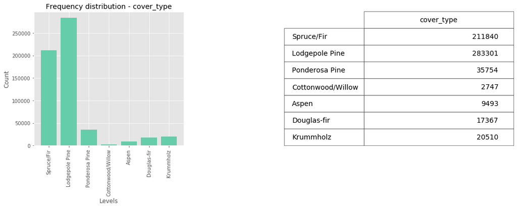

```python
inspect_freq_distribution(Data['cover_type'],['Spruce/Fir', 'Lodgepole Pine', 'Ponderosa Pine', 'Cottonwood/Willow', 'Aspen', 'Douglas-fir', 'Krummholz'])
```

### Resampling - Under sampling

From the bar plot above and the frequency table, it is observable that the target feature distribution is highly uneven. Hence the dataset is **'imbalanced'**. Imbalanced datasets have significantly higher instance count for some target levels than rest of the target levels. In our dataset, 'Cottonwood/Willow' has only 2747 instances, while 'Spruce/Fir' and 'Lodgepole Pine' levels have over 200,000 instances.

This kind of radically uneven distribution can adversly affect the performance of most of the machine learning algorithms including KNN, Naive Bayes etc.

We can deal with imbalanced datasets by resampling the dataset from the imbalanced dataset. There are two commonly used techiniques by which we can resample the dataset.

1. Under-sampling
   - It balances the dataset by reducing size of levels which are dominant in the distribution.
   - We keep a certain number of instances of minority levels, and then randomly select same number of instances from the other more dominant target levels.
   - This method is useful when we have sufficient number of observations in the dataset to make a workable resampled dataset.
2. Over-sampling
   - It balances the data by increasing the size of minority levels.
   - Here, new samples of minority level are added using various techinques like repeatation, SMOTE (Synthetic Minority Oversampling Technique) or bootstraping
   - This method is suitable when the number of instances in the dataset are insufficient.

Comparing both of these techniques, we find that undersampling is more suitable to our dataset, as our dataset offers a sufficient number instances of minority level.(Cottonwood/Willow - 2747).

```python
# !pip install imbalanced-learn
from imblearn.under_sampling import RandomUnderSampler

X = Data[['elevation', 'aspect', 'slope', 'horizontal_distance_to_hydrology',
            'vertical_distance_to_hydrology', 'horizontal_distance_to_roadways',
            'hillshade_9am', 'hillshade_noon', 'hillshade_3pm', 'horizontal_distance_to_fire_points',
            'rawah','neota','comanche_peak','cache_la_poudre',
            '2702', '2703', '2704', '2705', '2706', '2717', '3501', '3502', '4201', '4703',
            '4704', '4744', '4758', '5101', '5151', '6101', '6102', '6731', '7101', '7102',
            '7103', '7201', '7202', '7700', '7701', '7702', '7709', '7710', '7745', '7746',
            '7755', '7756','7757', '7790', '8703', '8707', '8708', '8771', '8772', '8776']]

Y = Data[['cover_type']]


rus = RandomUnderSampler(random_state=0)
rus.fit(X, Y)
X_resampled, y_resampled = rus.fit_resample(X, Y)


balanced_data = pd.DataFrame(X_resampled)
balanced_data['cover_type'] = y_resampled
balanced_data.columns = features
```

```
RandomUnderSampler(random_state=0)
```

We will examine the results of undersampling in next sections.

### Brief on categorical feature encoding

There are several ML Algorithms, which can directly deal with categorical data, such as decision trees and random forests. However, several other algorithms like K Nearest Neighbors can not understand categorical data directly, and hence needs the data to be encoded into a numerical format. There are several methods to perform the encoding, some of them being 'Integer encoding', 'one-hot encoding' and 'binary encoding' etc.

Integer encoding assigns a random or ordered integer value to each level of a categorical feature and is most simplest encoding technique and is easy to reverse it to interprete the results. However, it induces a false sense of order or comparability into the data, for example, if we encode Argentina -> 1 & Spain -> 2 algorithm may use 1 & 2 as absolute number and draw conclusions based on the fact that 1 < 2. Which can affect the model accuracy adversly.

One-hot encoding is useful when we have categorical features comparatively small number of levels than instances in the dataset. It creates sparse matrix, with all the levels added as new features, and marking 1 for presence of the that level for that observation & 0 otherwise. This technique is most commonly used encoding technique and is easy to reverse.

Binary encoding is useful when the number of levels in feature is very high, as it can represent 2^n levels with n features. for example, if there are 100 levels in a categorical feature, one-hot encoding the feature will result in a set 100 new features, while binary encoding can represent same information in 7 features ( 2^7 = 128 distinct values). However, it takes slightly more work to reverse it.

### One-hot encoding in the data

While this encoding makes the data more compaitable to classification algorithms we will be using in phase-II, understanding and visualizing the encoded data is rather complex. To make the further process of this report easier, we will reverse the encoding and append the original features derived from this process back to the data frame.

We have 54 features in total excluding target feature. It is also evident that 44 of these features are binary features, meaning that they have only two possible levels, 1 and 0, where 1 represents presence and 0 represents abscence.

Out of these 44 binary features, first 4. namely 'rawah','neota','comanche_peak' and 'cache_la_poudre' represent which to which wilderness the observation cell belongs. It is inferable that these 4 features are result of a 'one-hot' encoding on a original categorical feature 'Wilderness Area'.

Simillarly, rest of the 40 binary features '2702', '2703' etc. are result of applying 'one-hot' encoding to original feature 'Soil Type'.

Notice the simple function we used to reverse the one-hot encoding. Also notice the updated dimensions of the new dataset with two additional features 'soil_type' & 'wilderness_area' appended to the end of dataframe.

```python
def reverse_one_hot_encoding(row, x):
    for c in balanced_data[x].columns:
        if row[c]==1:
            return c

# Reversing one-hot encoding and appending the newly generated features back to original data
f1 = [['2702', '2703', '2704', '2705', '2706', '2717', '3501', '3502', '4201', '4703',
            '4704', '4744', '4758', '5101', '5151', '6101', '6102', '6731', '7101', '7102',
            '7103', '7201', '7202', '7700', '7701', '7702', '7709', '7710', '7745', '7746',
            '7755', '7756','7757', '7790', '8703', '8707', '8708', '8771', '8772', '8776']]
f2 = [['rawah','neota','comanche_peak','cache_la_poudre']]

balanced_data['soil_type'] = balanced_data.apply(reverse_one_hot_encoding, args=(f1), axis = 1)
balanced_data['wilderness_area'] = balanced_data.apply(reverse_one_hot_encoding, args=(f2), axis = 1)
balanced_data.head(3)
```

|  | elevation | aspect | slope | horizontal_distance_to_hydrology | vertical_distance_to_hydrology | horizontal_distance_to_roadways | hillshade_9am | hillshade_noon | hillshade_3pm | horizontal_distance_to_fire_points | ... | 7790 | 8703 | 8707 | 8708 | 8771 | 8772 | 8776 | cover_type | soil_type | wilderness_area |
| --- | --- | --- | --- | --- | --- | --- | --- | --- | --- | --- | --- | --- | --- | --- | --- | --- | --- | --- | --- | --- | --- |
| 0 | 3067 | 5 | 15 | 108 | 16 | 3691 | 200 | 210 | 146 | 1964 | ... | 0 | 0 | 0 | 0 | 0 | 0 | 0 | 1 | 7700 | comanche_peak |
| 1 | 3152 | 32 | 10 | 660 | 135 | 1727 | 218 | 218 | 134 | 2555 | ... | 0 | 0 | 0 | 0 | 0 | 0 | 0 | 1 | 7755 | comanche_peak |
| 2 | 2977 | 345 | 5 | 120 | 6 | 1718 | 209 | 231 | 160 | 3476 | ... | 0 | 0 | 0 | 0 | 0 | 0 | 0 | 1 | 7202 | rawah |

3 rows × 57 columns

```python
balanced_data.shape
```

```
(19229, 57)
```

### Summary Statistics & sanity checks

We will check the data for abnormal values. We will do so by checking the summary statistics and identify if there are any impossible value in the features. Consequently, we can say that there are no encoded null values as well.

From both tables below, it is evident that there are no abnormal values, some outliers may be present, but they are not errornous.

```python
display(HTML('<b>Table 1: Summary of continuous features</b>'))
display(balanced_data[continuous_feature_names].describe())

display(HTML('<b>Table 2: Summary of categorical binary features</b>'))
display(balanced_data[binary_feature_names + ['soil_type','wilderness_area','cover_type']].apply(lambda x: x.astype('category')).describe())
```

**Table 1: Summary of continuous features**

|  | elevation | aspect | slope | horizontal_distance_to_hydrology | vertical_distance_to_hydrology | horizontal_distance_to_roadways | hillshade_9am | hillshade_noon | hillshade_3pm | horizontal_distance_to_fire_points |
| --- | --- | --- | --- | --- | --- | --- | --- | --- | --- | --- |
| count | 19229.000000 | 19229.000000 | 19229.000000 | 19229.000000 | 19229.000000 | 19229.000000 | 19229.000000 | 19229.000000 | 19229.000000 | 19229.000000 |
| mean | 2749.982734 | 155.864111 | 16.511259 | 227.743772 | 50.845234 | 1716.758022 | 212.768735 | 218.951844 | 134.917416 | 1515.532737 |
| std | 417.554014 | 109.797225 | 8.488489 | 208.740273 | 60.426295 | 1329.783755 | 30.479572 | 22.829566 | 45.996592 | 1099.979442 |
| min | 1871.000000 | 0.000000 | 0.000000 | 0.000000 | -138.000000 | 0.000000 | 46.000000 | 97.000000 | 0.000000 | 0.000000 |
| 25% | 2380.000000 | 65.000000 | 10.000000 | 67.000000 | 5.000000 | 755.000000 | 196.000000 | 207.000000 | 106.000000 | 731.000000 |
| 50% | 2753.000000 | 125.000000 | 15.000000 | 180.000000 | 32.000000 | 1318.000000 | 220.000000 | 223.000000 | 138.000000 | 1273.000000 |
| 75% | 3108.000000 | 257.000000 | 22.000000 | 330.000000 | 79.000000 | 2285.000000 | 235.000000 | 235.000000 | 167.000000 | 1986.000000 |
| max | 3850.000000 | 360.000000 | 51.000000 | 1321.000000 | 588.000000 | 7082.000000 | 254.000000 | 254.000000 | 250.000000 | 7021.000000 |

**Table 2: Summary of categorical binary features**

|  | rawah | neota | comanche_peak | cache_la_poudre | 2702 | 2703 | 2704 | 2705 | 2706 | 2717 | ... | 7790 | 8703 | 8707 | 8708 | 8771 | 8772 | 8776 | soil_type | wilderness_area | cover_type |
| --- | --- | --- | --- | --- | --- | --- | --- | --- | --- | --- | --- | --- | --- | --- | --- | --- | --- | --- | --- | --- | --- |
| count | 19229 | 19229 | 19229 | 19229 | 19229 | 19229 | 19229 | 19229 | 19229 | 19229 | ... | 19229 | 19229 | 19229 | 19229 | 19229 | 19229 | 19229 | 19229 | 19229 | 19229 |
| unique | 2 | 2 | 2 | 2 | 2 | 2 | 2 | 2 | 2 | 2 | ... | 2 | 2 | 2 | 2 | 2 | 2 | 2 | 39 | 4 | 7 |
| top | 0 | 0 | 0 | 0 | 0 | 0 | 0 | 0 | 0 | 0 | ... | 0 | 0 | 0 | 0 | 0 | 0 | 0 | 4703 | comanche_peak | 7 |
| freq | 14732 | 18594 | 10951 | 13410 | 18786 | 18413 | 17986 | 18132 | 19036 | 18429 | ... | 19197 | 19110 | 19221 | 19185 | 18243 | 18382 | 18699 | 2689 | 8278 | 2747 |

4 rows × 47 columns

# Data Exploration

We will perform Data Exploration using visualisations and will perform,

- Univariate visualizations to understand general distribution of Data in individual descriptive features.
- Multivariate visualizations to better understand relationships among features.

As we have reversed the one-hot encoding, it will be easier to visualize the features using the newly added feature.

## Univariate visualizations

We will divide the Univariate visualizations portion in 2 parts,

- Exploration of categorical features
- Exploration of continuous features

To visualize categorical features, we will use bar plots, which is the general preference to explore data characteristics in nominal or small scale ordinal data. Barplots reflect the proportion of observation falling into particular categories.

To visualize continuous features, we will use histogram with overlayed density plots. These plots are preferred to examine general distribution of values in feature as well as skewness of distribution.

```python
# General graph styling for consistent layout across graphs
import seaborn as sns

plt.style.use('seaborn-white')
plt.rcParams['axes.edgecolor']='#FFFFFF'
plt.rcParams['axes.linewidth']=0
plt.rcParams['xtick.color']='#333F4B'
plt.rcParams['ytick.color']='#333F4B'
plt.rcParams['figure.figsize'] = 4.5, 3
```

#### Exploration of categorical features

##### Cover Type

As a result of resampling (undersampling) the dataset over target feature cover type, we can see that it has a flat distribution. Frequency table shows that all target levels have equal instance count of 2747 instances, making our dataset balanced over target feature level distribution.

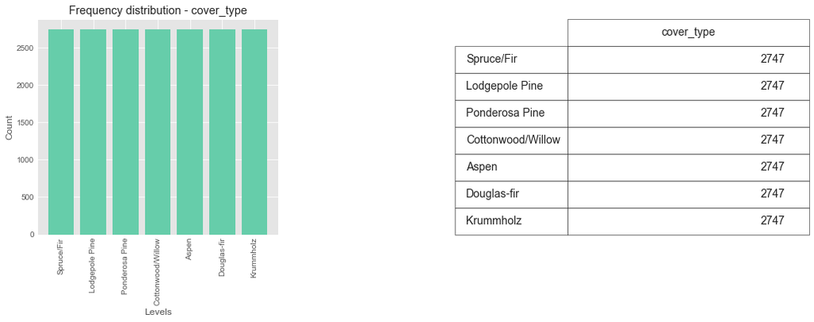

```python
inspect_freq_distribution(balanced_data['cover_type'],['Spruce/Fir', 'Lodgepole Pine', 'Ponderosa Pine', 'Cottonwood/Willow', 'Aspen', 'Douglas-fir', 'Krummholz'])
```

##### Wilderness Area

[figure not shown]

```python
inspect_freq_distribution(balanced_data['wilderness_area'],['rawah','neota','comanche_peak','cache_la_poudre'])
```

##### Soil Type Count

The horizontal lolipop plot below shows the frequency distribution of levels of feature 'soil_type'. The labels on Y axis are the USFS (United States Forest Services) soil type codes, latest version of these codes and their associated soil type can be found at - https://www.fs.fed.us/nrm/documents/fsveg/cse_user_guides/R8FG_appendix.pdf.

From the graph we can see a non uniform distribution, with some levels like '4703', '7745' & '2704' occupying significantly more number of observations. Other levels at the bottom of the Y axis like '5151' & '3502' have very low frequency.

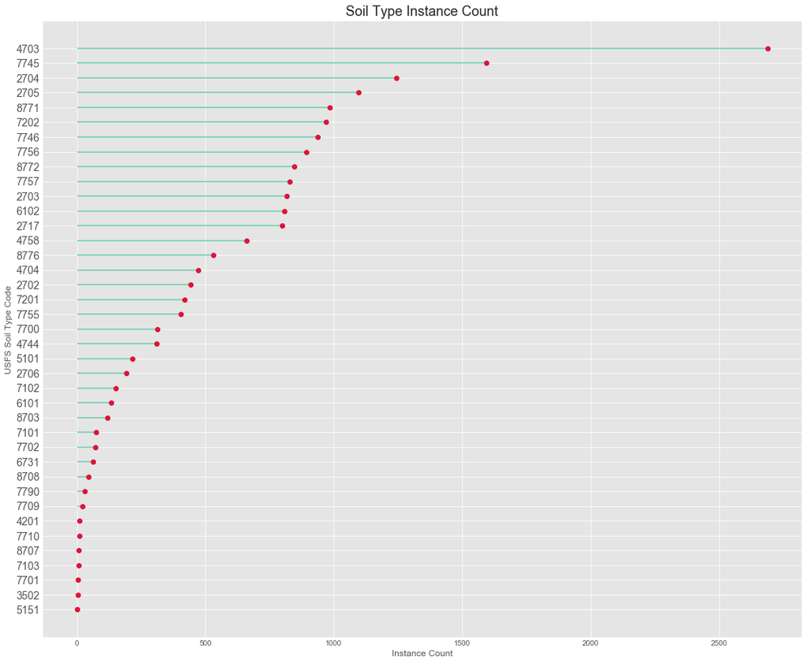

```python
ordered_df = pd.DataFrame(balanced_data['soil_type'].value_counts().sort_values())
ordered_df.head(39)

my_range=range(1,len(ordered_df.index)+1)

plt.figure(figsize=(18,15))
plt.hlines(y=my_range, xmin=0, xmax=ordered_df['soil_type'], color='mediumaquamarine')
plt.plot(ordered_df['soil_type'], my_range, "o", color = 'crimson')
# Add titles and axis names
plt.yticks(my_range, ordered_df.index,  fontsize = 14)
plt.title("Soil Type Instance Count", fontdict={'fontsize': 18, 'fontweight': 'medium'})
plt.xlabel('Instance Count')
plt.ylabel('USFS Soil Type Code')
plt.show();
```

#### Exploration of continuous features

We have plotted side by side plots for continuous features 'elevation', 'aspect', 'slope', 'horizontal_distance_to_hydrology', 'vertical_distance_to_hydrology', 'horizontal_distance_to_roadways', 'hillshade_9am', 'hillshade_noon', 'hillshade_3pm', 'horizontal_distance_to_fire_points'.

We will examine relationships among these feature in a more detailed manner in next section.

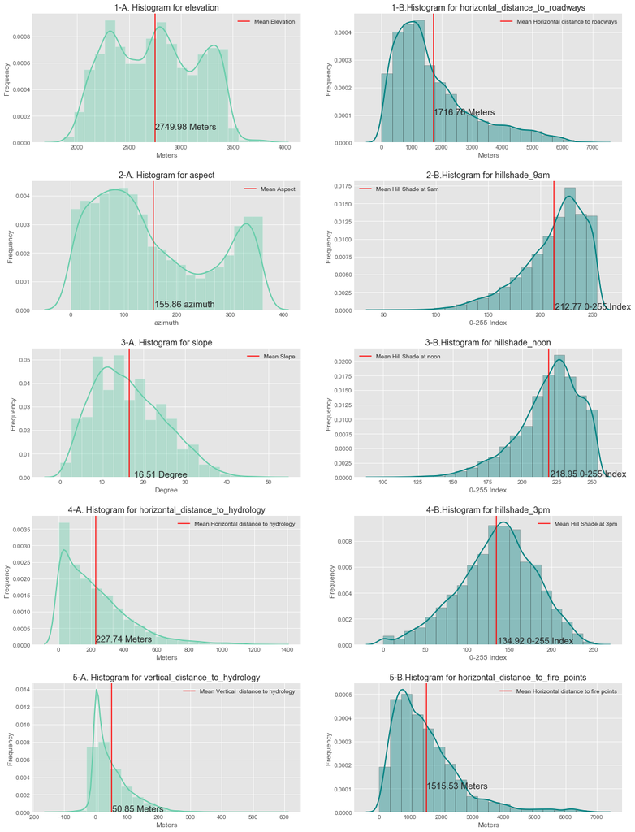

```python
plot1 = ['elevation', 'aspect', 'slope', 'horizontal_distance_to_hydrology',
            'vertical_distance_to_hydrology']
plot2 = ['horizontal_distance_to_roadways', 'hillshade_9am', 'hillshade_noon',
         'hillshade_3pm', 'horizontal_distance_to_fire_points']

exLabelsA = ["Elevation", "Aspect", "Slope", \
             "Horizontal distance to hydrology","Vertical  distance to hydrology" ]
xLabelsA = ["Meters", "azimuth", "Degree", "Meters","Meters"]
exLabelsB = ["Horizontal distance to roadways", "Hill Shade at 9am", \
             "Hill Shade at noon", "Hill Shade at 3pm","Horizontal distance to fire points", ]
xLabelsB = ["Meters", "0-255 Index", "0-255 Index", "0-255 Index","Meters"]

fig, axs = plt.subplots(nrows = 5, ncols=2, figsize=(18,25))

i=0
sns.despine(left = True)

for f1,f2 in zip(plot1,plot2):

    mean1 = round(balanced_data[f1].mean(), 2)
    mean2 = round(balanced_data[f2].mean(), 2)

    sns.distplot(balanced_data[f1], hist=True, kde=True, bins=int(20), color =\
                 'mediumaquamarine', ax = axs[i][0], hist_kws={'edgecolor':'white'},\
                 kde_kws={'linewidth': 2})

    l1 = axs[i][0].axvline(x= mean1, label='Mean ' + exLabelsA[i], c='r')

    axs[i][0].text(x=  mean1 + 1.2, y = 0.0001, s=str(mean1)+" "+ xLabelsA[i], \
                   fontsize = 15 )
    axs[i][0].set_title(str(i+1)+"-A. Histogram for " + f1 )
    axs[i][0].set_ylabel("Frequency")
    axs[i][0].set_xlabel(xLabelsA[i])
    axs[i][0].legend(loc = "best")

    sns.distplot(balanced_data[f2], hist=True, kde=True,  bins=int(20), color = \
                 'teal', ax = axs[i][1], hist_kws={'edgecolor':'black'}, \
                 kde_kws={'linewidth': 2})

    l2 = axs[i][1].axvline(x= mean2, label='Mean ' + exLabelsB[i], c='r')
    axs[i][1].text(x= mean2 + 1.2, y = 0.0001, s=str(mean2)+" "+ xLabelsB[i],\
                   fontsize = 15)
    axs[i][1].set_title(str(i+1)+"-B.Histogram for " + f2)
    axs[i][1].set_ylabel("Frequency")
    axs[i][1].set_xlabel(xLabelsB[i])
    axs[i][1].legend(loc = "best")

    i+=1
plt.subplots_adjust(hspace = 0.3)
plt.show();
```

## Multivariate Visualization

### Categorized box plots

In this section, we will inspect underlaying relationships between various continuous variables with respect to their corresponding target feature level. We will use box plots grouped by cover_type. We can state some plausible hypothesises based on inferences we make by examining the plots.

##### Elevation by Cover Type

Following box plot shows some significant insights. It is rather understandable that some tree species are more suitable to high altitude and some are more commonly found at lower altitude. By plotting the elevation grouped by cover type, we can have a rough idea on which forest cover type designation is commonly found at a particular range of elevation.

Considering the plots 1-A, We can observe following insights

- 'Krummholz' forests have heavy presence at higher altitude( more than 3300 meters).
- 'Spruce-Fir' forests are also found at high altitudes which is slightly lower than 'Krummholz' forests.
- 'Cottonwillow' cover type is generally found at the bottom of valleys near surface water sources or in shallow waters around banks of lakes and rivers. Which confirms with it having lowest elevation, as water sources will be in the valley with low elevation.
- Elevation has a significant impact on cover type, as different levels of cover types have a rather significant difference in their elevation ranges.
- From 1-B, we can see that 'Krummholz' & 'Spruce-Fir' are relatively farther from roadways, while 'Aspen', 'Douglas-fir' & 'Ponderosa Pine' are comparatively near to roadways.
- From 4-A & 5-A, we can see 'Krummholz' is relatively far from hydrology (Water sources), which makes sense considering high elevation. This observation can be used to propose a hypothesis - 'as elevation increases, distance from the hydrology increases.' We will confirm the hypothesis in a later section.
- From 1-A & 5-B, it is observable that the areas at higher altitudes are farther away from the fire starting points. They are also farther away from roadways and hydrology. It will be worthwhile to check if these features are correlated or not.
- There are no meaningful insights which can be gathered from hillshade features and aspect feature. Wide and overlapping ranges among groups do point towards high shannon's entropy values however.

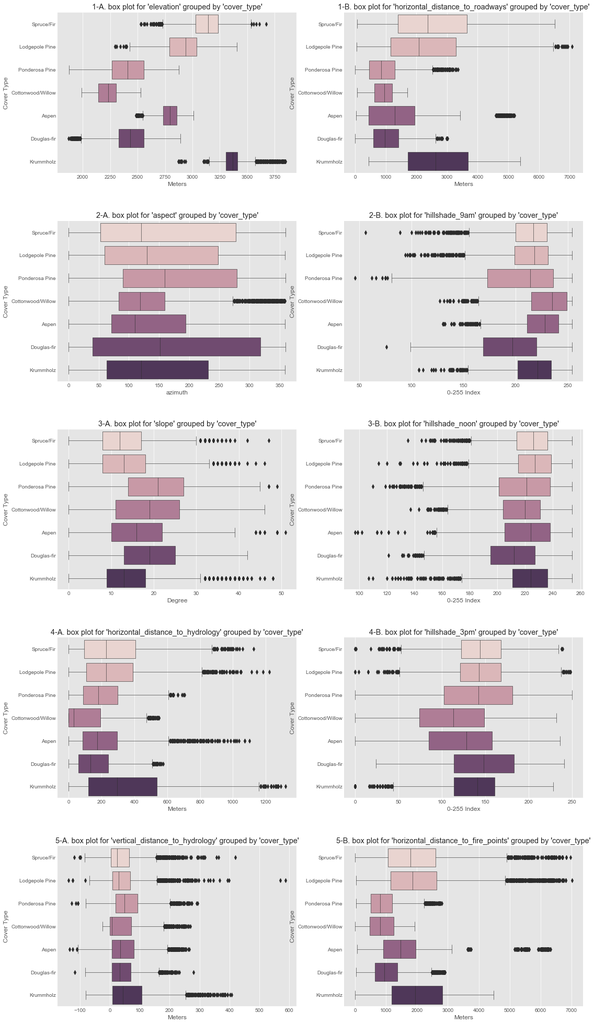

```python
dic = {'cover_type': {1:'Spruce/Fir', 2:'Lodgepole Pine', 3:'Ponderosa Pine', 4:'Cottonwood/Willow', 5:'Aspen', 6:'Douglas-fir', 7:'Krummholz'}}
temp_data = balanced_data.replace(dic)


plot1 = ['elevation', 'aspect', 'slope', 'horizontal_distance_to_hydrology', \
            'vertical_distance_to_hydrology']
plot2 = ['horizontal_distance_to_roadways', 'hillshade_9am', 'hillshade_noon',\
         'hillshade_3pm', 'horizontal_distance_to_fire_points']


exLabelsA = ["Elevation", "Aspect", "Slope", "Horizontal distance to hydrology",\
             "Vertical  distance to hydrology", ]
xLabelsA = ["Meters", "azimuth", "Degree", "Meters","Meters"]
exLabelsB = ["Horizontal distance to roadways", "Hill Shade at 9am", \
             "Hill Shade at noon", "Hill Shade at 3pm",\
             "Horizontal distance to fire points", ]
xLabelsB = ["Meters", "0-255 Index", "0-255 Index", "0-255 Index","Meters"]

fig, axs = plt.subplots(nrows = 5, ncols=2, figsize=(18,35))

i=0
sns.despine(left = True)

for f1,f2 in zip(plot1,plot2):
    sns.boxplot(x=temp_data[f1],y = temp_data['cover_type'], orient="h", palette=sns.cubehelix_palette(8), ax = axs[i][0],linewidth=0.6)
    axs[i][0].set_title(str(i+1)+"-A. box plot for '" + str(f1) + "' grouped by 'cover_type'" )
    axs[i][0].set_ylabel("Cover Type")
    axs[i][0].set_xlabel(xLabelsA[i])
    sns.boxplot(x=temp_data[f2],y = temp_data['cover_type'], orient="h", palette=sns.cubehelix_palette(8),ax = axs[i][1], linewidth=0.6)
    axs[i][1].set_title(str(i+1)+"-B. box plot for '" + str(f2) + "' grouped by 'cover_type'")
    axs[i][1].set_ylabel("Cover Type")
    axs[i][1].set_xlabel(xLabelsB[i])
    i+=1
plt.subplots_adjust(hspace = 0.3)
plt.show();
```

### Boxplot for 'Soil Type'-wise Elevation

We have already seen that certain cover types like 'Spruce-fir' & 'Krummholz' are more likely to be found at higher altitudes. It will be interesting to see if same applies to soil types.

[figure not shown]

```python
#figure(num=None, figsize=(15, 20), dpi=80, facecolor='w', edgecolor='k')
plt.figure(figsize=(18,15))
plt.style.use("seaborn-dark")
sns.boxplot(x="soil_type", y="elevation", data=temp_data,  color = "teal", linewidth = 0.5, showfliers = False)
plt.title("Boxplot for Location wise Rainfall in mm \
subcategorised by RainToday",fontsize=15 )
plt.ylabel("Elevation",fontsize=15)
plt.xlabel("Rainfall in mm",fontsize=10)
plt.xlim(-1,39)


plt.show();
```

In the following plot, we have two subplots, a heatmap to examine the how target cover types are distributed over soil type. To aggregate the data, we have appended a temparory column 'count'. Basically we are counting how many instances falls in a particular (cover_type level, soil_type level) pair. Second subplot plots mean elevation grouped by soil_type. From second subplot, we can have rough estimate which soil types are more prone to be found at higher elevations.

Combining information from these two plots, following observations can be made

- 'Krummholz' forms a dense cluster near Soil types '8771', '8772' & '8776', all of which are found at high altitudes.
- 'Lodgepole Pine' is pretty versatile forest type, it has presence from shallowest elevation of dataset to some of the highest elevations and can be found with most of all observed soil types.
- 'Spruce-fir' & 'Lodgepole Pine' both form a dense cluster on soil types 7745, 7746, 7755, 7756, 7757. These soil types are found at sub alpine elevations, which makes 'Spruce-fir' & 'Lodgepole Pine' a more occupying cover type at sub-alpine heights.
- Aspen also forms a cluster at roughly same height and same soil_types, but in general, the cluster is bit left shifted.
- 'Cottonwood/willow' & 'Ponderosa pine' have a dense occurance on the left side of heatmap, which contains soil types which are prone to appear at lower altitudes.
- Soil type '5151' has exceptionally low elevation and suprisingly low instances count, with only 'some instances of 'Douglas-Fir' occupying 0-250 instances. However, roughlt more than half of 'Douglas-fir' instances (out of 2747), occurs in '4703' soil type.

Some of these observations can be a result of undersampling. but in and all, plots combined do show some intersting insights.

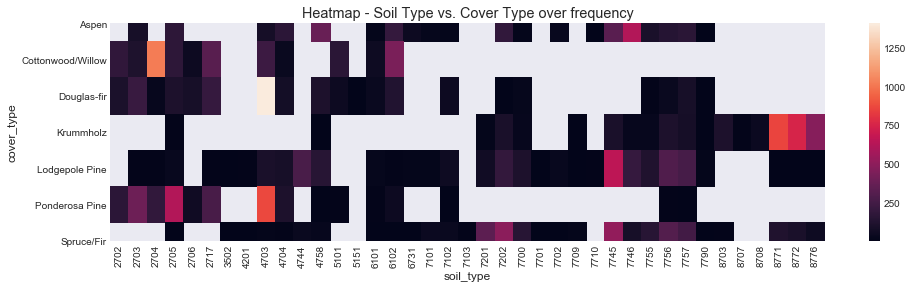

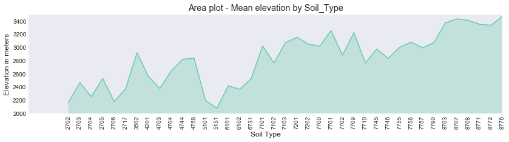

```python
temp_data['count'] = 1

df_count_covertype_by_soiltype = temp_data[['soil_type','cover_type','count']].pivot_table(values='count',index='cover_type',columns='soil_type',aggfunc=np.sum)
df_mean_elevation_soiltype = temp_data[['soil_type','elevation']].pivot_table(values='elevation',columns='soil_type',aggfunc=np.mean)

x = range(1,len(list(df_mean_elevation_soiltype.columns))+1)
y = df_mean_elevation_soiltype.values[0]

fig, axs = plt.subplots(nrows = 1, ncols=1, figsize=(16,4))

sns.heatmap(df_count_covertype_by_soiltype, annot=False)
plt.title("Heatmap - Soil Type vs. Cover Type over frequency")
plt.show();

plt.figure(figsize=(14,3))
plt.fill_between(x, y, color = "mediumaquamarine", alpha = 0.3)
plt.plot(x, y, color="mediumaquamarine", alpha=1)
plt.xticks(ticks = x,labels = df_mean_elevation_soiltype.columns, rotation = 90)
plt.xlim(-2.5,39)
plt.ylim(2000,3500)
plt.ylabel("Elevation in meters")
plt.xlabel("Soil Type")
plt.title("Area plot - Mean elevation by Soil_Type")
plt.show();
```

We plotted similar heatmap of 'wilderness area' and 'covertype'. We can make following inferences from the plot,

- 'Cottonwood/Willow' is present only in 'couche la poudre' wilderness. It can mean that 'couche al poudre' has comparatively lower mean elevation.
- 'Lodgepole pine' is present in all 4 areas. which can be attributed to it's greater frequency in dataset.
- 'Aspen' is present in 'commanche peak' and 'rawah' areas.

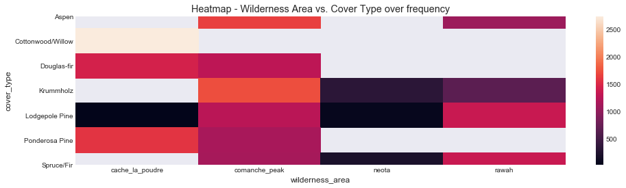

```python
df_count_covertype_by_soiltype = temp_data[['wilderness_area','cover_type','count']]\
.pivot_table(values='count',index='cover_type',columns='wilderness_area',aggfunc=np.sum)

x = range(1,len(list(df_mean_elevation_soiltype.columns))+1)
y = df_mean_elevation_soiltype.values[0]


fig, axs = plt.subplots(figsize=(16,4))

sns.heatmap(df_count_covertype_by_soiltype, annot=False)
plt.title("Heatmap - Wilderness Area vs. Cover Type over frequency")
plt.show();
```

### Data partition and export

We have partitioned data into training and testing datasets and export them to csv files, which we will be using in the next phase of the project to feed to the ML Algorithms. We have used 70% : 30% ratio for train test pairs. We have made 2 pairs of the dataset, one with reversed one-hot encoded features 'soil_type' & 'wilderness_area' and the other pair with 44 one-hot encoded features. The main reasons for doing that is that Algorithms like decision trees and random forests can directly deal with the categorical features. Adding 44 extra features instead of 2 categorical features will create unnecessary overhead for the algorithm. However, we will use both pairs of dataset to see how encoding affects alogrithm's running time and performance.

We have done integer encoding on the dataset with categorical features 'soil_type' and 'wilderness_areas'.

We will also standardize the data with centering and scaling. We are choosing not to normalize because we have not removed outliers from the data, as they were of significance to us. We will keep both sets of data, one with standardization applied and one without it, to see the effects of stadardization on the dataset.

```python
onehot_data.head()
```

|  | elevation | aspect | slope | horizontal_distance_to_hydrology | vertical_distance_to_hydrology | horizontal_distance_to_roadways | hillshade_9am | hillshade_noon | hillshade_3pm | horizontal_distance_to_fire_points | ... | 7756 | 7757 | 7790 | 8703 | 8707 | 8708 | 8771 | 8772 | 8776 | cover_type |
| --- | --- | --- | --- | --- | --- | --- | --- | --- | --- | --- | --- | --- | --- | --- | --- | --- | --- | --- | --- | --- | --- |
| 0 | 3067 | 5 | 15 | 108 | 16 | 3691 | 200 | 210 | 146 | 1964 | ... | 0 | 0 | 0 | 0 | 0 | 0 | 0 | 0 | 0 | 1 |
| 1 | 3152 | 32 | 10 | 660 | 135 | 1727 | 218 | 218 | 134 | 2555 | ... | 0 | 0 | 0 | 0 | 0 | 0 | 0 | 0 | 0 | 1 |
| 2 | 2977 | 345 | 5 | 120 | 6 | 1718 | 209 | 231 | 160 | 3476 | ... | 0 | 0 | 0 | 0 | 0 | 0 | 0 | 0 | 0 | 1 |
| 3 | 3221 | 106 | 9 | 192 | 1 | 2768 | 235 | 229 | 125 | 872 | ... | 0 | 0 | 0 | 0 | 0 | 0 | 0 | 0 | 0 | 1 |
| 4 | 3194 | 4 | 15 | 499 | 67 | 2255 | 200 | 211 | 147 | 3404 | ... | 0 | 0 | 0 | 0 | 0 | 0 | 0 | 0 | 0 | 1 |

5 rows × 55 columns

```python
# categorical_data = balanced_data[['elevation', 'aspect', 'slope', 'horizontal_distance_to_hydrology',
#             'vertical_distance_to_hydrology', 'horizontal_distance_to_roadways',
#             'hillshade_9am', 'hillshade_noon', 'hillshade_3pm', 'horizontal_distance_to_fire_points',
#             'wilderness_area','soil_type','cover_type']]

# onehot_data = balanced_data[['elevation', 'aspect', 'slope', 'horizontal_distance_to_hydrology',
#             'vertical_distance_to_hydrology', 'horizontal_distance_to_roadways',
#             'hillshade_9am', 'hillshade_noon', 'hillshade_3pm', 'horizontal_distance_to_fire_points',
#             'rawah','neota','comanche_peak','cache_la_poudre',
#             '2702', '2703', '2704', '2705', '2706', '2717', '3501', '3502', '4201', '4703',
#             '4704', '4744', '4758', '5101', '5151', '6101', '6102', '6731', '7101', '7102',
#             '7103', '7201', '7202', '7700', '7701', '7702', '7709', '7710', '7745', '7746',
#             '7755', '7756','7757', '7790', '8703', '8707', '8708', '8771', '8772', '8776',
#             'cover_type']]

# Exporting for phase 2

onehot_data[['elevation', 'aspect', 'slope', 'horizontal_distance_to_hydrology',
            'vertical_distance_to_hydrology', 'horizontal_distance_to_roadways',
            'hillshade_9am', 'hillshade_noon', 'hillshade_3pm', 'horizontal_distance_to_fire_points',
            'rawah','neota','comanche_peak','cache_la_poudre',
            '2702', '2703', '2704', '2705', '2706', '2717', '3501', '3502', '4201', '4703',
            '4704', '4744', '4758', '5101', '5151', '6101', '6102', '6731', '7101', '7102',
            '7103', '7201', '7202', '7700', '7701', '7702', '7709', '7710', '7745', '7746',
            '7755', '7756','7757', '7790', '8703', '8707', '8708', '8771', '8772', '8776']].to_csv(r'descriptive_data.csv',header=None, index=None)
onehot_data['cover_type'].to_csv(r'target_data.csv', header = None, index = None)

# # encoding the lebels
# lb_make = LabelEncoder()
# categorical_data['soil_type'] = lb_make.fit_transform(categorical_data['soil_type'])
# categorical_data['wilderness_area'] = lb_make.fit_transform(categorical_data['wilderness_area'])

# categorical_x = categorical_data[['elevation', 'aspect', 'slope', 'horizontal_distance_to_hydrology',
#             'vertical_distance_to_hydrology', 'horizontal_distance_to_roadways',
#             'hillshade_9am', 'hillshade_noon', 'hillshade_3pm', 'horizontal_distance_to_fire_points',
#             'wilderness_area','soil_type']]
# categorical_x.shape
# categorical_y = categorical_data['cover_type']
# categorical_scaled_x = preprocessing.MinMaxScaler().fit_transform(categorical_x)
# categorical_scaled_x.shape
# categorical_train_data, categorical_test_data, categorical_train_labels, categorical_test_labels =\
# train_test_split(categorical_scaled_x, categorical_y, test_size=0.30, random_state=42)

# # onehot encoded data
# onehot_data_x = balanced_data[['elevation', 'aspect', 'slope', 'horizontal_distance_to_hydrology',
#             'vertical_distance_to_hydrology', 'horizontal_distance_to_roadways',
#             'hillshade_9am', 'hillshade_noon', 'hillshade_3pm', 'horizontal_distance_to_fire_points',
#             'rawah','neota','comanche_peak','cache_la_poudre',
#             '2702', '2703', '2704', '2705', '2706', '2717', '3501', '3502', '4201', '4703',
#             '4704', '4744', '4758', '5101', '5151', '6101', '6102', '6731', '7101', '7102',
#             '7103', '7201', '7202', '7700', '7701', '7702', '7709', '7710', '7745', '7746',
#             '7755', '7756','7757', '7790', '8703', '8707', '8708', '8771', '8772', '8776']]
# onehot_data_y = balanced_data['cover_type']
# onehot_data_scaled_x = preprocessing.MinMaxScaler().fit_transform(onehot_data_x)
# onehot_train_data, onehot_test_data, onehot_train_labels, onehot_test_labels = \
# train_test_split(onehot_data_scaled_x, onehot_data_y, test_size=0.30, random_state=42)


# pd.DataFrame(categorical_train_data).to_csv(r'categorical_train_data.csv',header=None, index=None)
# pd.DataFrame(categorical_test_data).to_csv(r'categorical_test_data.csv',header=None, index=None)
# pd.DataFrame(categorical_train_labels).to_csv(r'categorical_train_labels.csv',header=None, index=None)
# pd.DataFrame(categorical_test_labels).to_csv(r'categorical_test_labels.csv',header=None, index=None)


# pd.DataFrame(onehot_train_data).to_csv(r'onehot_train_data.csv',header=None, index=None)
# pd.DataFrame(onehot_test_data).to_csv(r'onehot_test_data.csv',header=None, index=None)
# pd.DataFrame(onehot_train_labels).to_csv(r'onehot_train_labels.csv',header=None, index=None)
# pd.DataFrame(onehot_test_labels).to_csv(r'onehot_test_labels.csv',header=None, index=None)
```

# Summary

# Phase 2 - Modelling & Hyperparameter tuning

```python
# To display output of all the statements and not only last statement
from IPython.core.interactiveshell import InteractiveShell
InteractiveShell.ast_node_interactivity = "all"

import warnings
warnings.simplefilter("ignore")

import pandas as pd
import numpy as np
import seaborn as sns
import matplotlib.pyplot as plt
from sklearn import preprocessing
from IPython.display import display, HTML
from sklearn.preprocessing import LabelEncoder
from sklearn.model_selection import train_test_split
from sklearn.neighbors import KNeighborsClassifier
from sklearn.metrics import precision_recall_fscore_support as score
from sklearn.preprocessing import MinMaxScaler
from sklearn.metrics import confusion_matrix
from pandas.plotting import parallel_coordinates
from sklearn.metrics import precision_recall_fscore_support as score
from sklearn.tree import DecisionTreeClassifier
from sklearn.ensemble import RandomForestClassifier
from sklearn.metrics import roc_curve, auc
from sklearn.metrics import classification_report

from sklearn.preprocessing import MinMaxScaler
from sklearn.preprocessing import RobustScaler
from sklearn.preprocessing import StandardScaler

from mpl_toolkits.mplot3d import Axes3D
```

```python
descriptives_file = "descriptive_data.csv"
target_file = "target_data.csv"
```

```python
data_features = ['elevation', 'aspect', 'slope', 'horizontal_distance_to_hydrology',
            'vertical_distance_to_hydrology', 'horizontal_distance_to_roadways',
            'hillshade_9am', 'hillshade_noon', 'hillshade_3pm', \
            'horizontal_distance_to_fire_points',
            'rawah','neota','comanche_peak','cache_la_poudre',
            '2702', '2703', '2704', '2705', '2706', '2717', '3501', \
            '3502', '4201', '4703', '4704', '4744', '4758', '5101', \
            '5151', '6101', '6102', '6731', '7101', '7102', '7103', \
            '7201', '7202', '7700', '7701', '7702', '7709', '7710', \
            '7745', '7746', '7755', '7756','7757', '7790', '8703', \
            '8707', '8708', '8771', '8772', '8776']

label_feature = ['cover_type']

# data is encoded , undersampled, preprocessed
descriptives = pd.read_csv(descriptives_file, names = data_features)
target = pd.read_csv(target_file, names = label_feature)

print("Descriptive Features Check:")
print("Shape:")
descriptives.shape
descriptives.head()

print(" ")
print("Target Feature Check:")
print("Shape:")
target.shape
target.head()
```

```
Descriptive Features Check:
Shape:
```

```
(19229, 54)
```

|  | elevation | aspect | slope | horizontal_distance_to_hydrology | vertical_distance_to_hydrology | horizontal_distance_to_roadways | hillshade_9am | hillshade_noon | hillshade_3pm | horizontal_distance_to_fire_points | ... | 7755 | 7756 | 7757 | 7790 | 8703 | 8707 | 8708 | 8771 | 8772 | 8776 |
| --- | --- | --- | --- | --- | --- | --- | --- | --- | --- | --- | --- | --- | --- | --- | --- | --- | --- | --- | --- | --- | --- |
| 0 | 3067 | 5 | 15 | 108 | 16 | 3691 | 200 | 210 | 146 | 1964 | ... | 0 | 0 | 0 | 0 | 0 | 0 | 0 | 0 | 0 | 0 |
| 1 | 3152 | 32 | 10 | 660 | 135 | 1727 | 218 | 218 | 134 | 2555 | ... | 1 | 0 | 0 | 0 | 0 | 0 | 0 | 0 | 0 | 0 |
| 2 | 2977 | 345 | 5 | 120 | 6 | 1718 | 209 | 231 | 160 | 3476 | ... | 0 | 0 | 0 | 0 | 0 | 0 | 0 | 0 | 0 | 0 |
| 3 | 3221 | 106 | 9 | 192 | 1 | 2768 | 235 | 229 | 125 | 872 | ... | 0 | 0 | 0 | 0 | 0 | 0 | 0 | 0 | 0 | 0 |
| 4 | 3194 | 4 | 15 | 499 | 67 | 2255 | 200 | 211 | 147 | 3404 | ... | 1 | 0 | 0 | 0 | 0 | 0 | 0 | 0 | 0 | 0 |

5 rows × 54 columns

```
Target Feature Check:
Shape:
```

```
(19229, 1)
```

|  | cover_type |
| --- | --- |
| 0 | 1 |
| 1 | 1 |
| 2 | 1 |
| 3 | 1 |
| 4 | 1 |

# Feature selection

We have 54 descriptive features including continuos and encoded features. In this section, we will identify 10 relevent features contributing more to target feature cover type on the bases of calculated feature importance scores. Feature selection will be included into pipeline later on. This analysis plays signinficant role to improve model efficiency and avoid overfitting.

RandomForestClassifier generated importance scores and list of 10 relevent features in the section below. Also, we can derive from the ranking plot for score that features like elevation, horizontal distances has higher relevence than hillshade features. During pipelining we will explore the subset of features which works better with perticular model.

```python
# Feature Selection
from sklearn.ensemble import RandomForestClassifier

print("Feature Selection using RandomForestClassifier:")
features_count = 20
model_rfi_selection = RandomForestClassifier(n_estimators=100)
model_rfi_selection.fit(descriptives, target)
fs_indices_rfi = np.argsort(model_rfi_selection.feature_importances_)[::-1][0:features_count]

best_features_rfi_selection = descriptives.columns[fs_indices_rfi].values
print("-------------------------------------------------------------------------------")
print("Best Selected features:")
best_features_rfi_selection

feature_importances_rfi = model_rfi_selection.feature_importances_[fs_indices_rfi]
print("-------------------------------------------------------------------------------")
print("Feature Importance scores generated for best selected features:")
feature_importances_rfi
```

```
Feature Selection using RandomForestClassifier:
```

```
RandomForestClassifier()
```

```
-------------------------------------------------------------------------------
Best Selected features:
```

```
array(['elevation', 'horizontal_distance_to_roadways',
       'horizontal_distance_to_fire_points',
       'horizontal_distance_to_hydrology',
       'vertical_distance_to_hydrology', 'hillshade_9am', 'aspect',
       'cache_la_poudre', 'hillshade_3pm', 'hillshade_noon', 'slope',
       '4703', '8771', '8772', 'rawah', 'comanche_peak', '2704', '2705',
       '8776', '7746'], dtype=object)
```

```
-------------------------------------------------------------------------------
Feature Importance scores generated for best selected features:
```

```
array([0.23564085, 0.09177269, 0.07270143, 0.06025817, 0.05330793,
       0.05215645, 0.04862663, 0.048483  , 0.04537648, 0.0437546 ,
       0.03667072, 0.02223773, 0.01954836, 0.01882854, 0.01672465,
       0.01654441, 0.01616617, 0.01297034, 0.00950707, 0.00728413])
```

Let's visualize the result using features importance to get overview of target feature dependency.

```
Visual representation of selected features
```

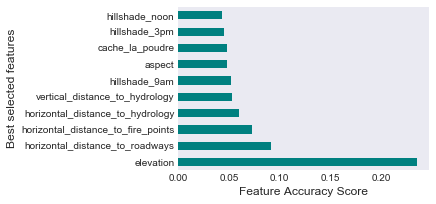

```python
print("Visual representation of selected features")
# Plot graph for feature selection
feature_importances = pd.Series(feature_importances_rfi, index=best_features_rfi_selection)
feature_importances.nlargest(10).plot(kind='barh', color= 'teal')
plt.xlabel("Feature Accuracy Score")
plt.ylabel("Best selected features")
plt.show();
```

# Data Sampling

Original dataset has 581012 observations with uneven distribution of target feature 'cover type'. This highly imbalanced nature of data set can adversely affect the performance of most of the machine learning algorithms. Cover type has only 2747 instances of '‘Cottonwood/Willow’ category which is the minimum count among target categories. To overcome this issue we have already undersampled the dateset using RandomUnderSampler. As we have sufficient number of instances in minority category, we have chosen undersampling technique to resample the data. Final undersampled data to be used for model fitting has 19229 observations.

# Data Split

Here, we divide total 19229 observations into training and testing sets for descriptive features and target features in split of 80:20 of train:test data. We will use train_test_split() with 0.20 test_size parameter value to perform this operation.

```python
# Data split
x_train, x_test, y_train, y_test = train_test_split(descriptives, target, test_size = 0.20, random_state = 0)
```

```python
print("x_train Shape")
x_train.shape
print("x_test Shape")
x_test.shape
```

[output not shown]

# Scaling

Most of the machine learning algorithm works well with scaled data. Highly varying magnitude of data impacts outcome of algorithm which uses distance based techniques. Therefore it is always preferable to scale data before feeding it to alorithms. We will use MinMaxScaler to scale values between 0 to 1. Considering that it preserves the orginal distribution of data and doesn't reduce importance of outliers.

```python
# Scaling
scaler_min = MinMaxScaler()
scaler_min = scaler_min.fit(x_train)
x_train = scaler_min.transform(x_train)
x_test = scaler_min.transform(x_test)
```

# Model Evaluation Strategy

We have chosen to use accuracy as evaluation metric, as our problem is multiclass classification problem and accuracy is prefered choice for these type of problems.

We will evaluate our models with paired t-test on accuracy. We will use 5-fold crossvalidation with pipeline to perform gird search to find optimal parameter values for hyper parameter tuning. We will use around 16000 instances for cross validation and tuning, and later on will use around 4000 instances to test our models with optimal parameters.

We have multiple functions which will help us perform feature selection & extracting results from the pipeline. Function are provided by RMIT University Coursse tutorial - https://rmit.instructure.com/courses/50786/files/7870346?fd_cookie_set=1.

```python
# Hyper parameter tuning
from sklearn.model_selection import StratifiedKFold, GridSearchCV

cv_method = StratifiedKFold(n_splits=5, random_state=999)
```

```python
from sklearn.base import BaseEstimator, TransformerMixin

# custom function for RFI feature selection inside a pipeline
# here we use n_estimators=100
class RFIFeatureSelector(BaseEstimator, TransformerMixin):

    # class constructor
    # make sure class attributes end with a "_"
    # per scikit-learn convention to avoid errors
    def __init__(self, n_features_=10):
        self.n_features_ = n_features_
        self.fs_indices_ = None

    # override the fit function
    def fit(self, X, y):
        from sklearn.ensemble import RandomForestClassifier
        from numpy import argsort
        model_rfi = RandomForestClassifier(n_estimators=100)
        model_rfi.fit(X, y)
        self.fs_indices_ = argsort(model_rfi.feature_importances_)[::-1][0:self.n_features_]
        return self

    # override the transform function
    def transform(self, X, y=None):
        return X[:, self.fs_indices_]
```

```python
# custom function to format the search results as a Pandas data frame

def get_search_results(gs):

    def model_result(scores, params):
        scores = {'mean_score': np.mean(scores),
             'std_score': np.std(scores),
             'min_score': np.min(scores),
             'max_score': np.max(scores)}
        return pd.Series({**params,**scores})

    models = []
    scores = []

    for i in range(gs.n_splits_):
        key = f"split{i}_test_score"
        r = gs.cv_results_[key]
        scores.append(r.reshape(-1,1))

    all_scores = np.hstack(scores)
    for p, s in zip(gs.cv_results_['params'], all_scores):
        models.append((model_result(s, p)))

    pipe_results = pd.concat(models, axis=1).T.sort_values(['mean_score'], ascending=False)

    columns_first = ['mean_score', 'std_score', 'max_score', 'min_score']
    columns = columns_first + [c for c in pipe_results.columns if c not in columns_first]

    return pipe_results[columns]
```

# Hyper parameter tuning

We will use pipeline to perform gridsearch on training dataset to find optimal value of parameteres for different classification algorithms. To compare the performance, we will use K-Fold Cross Validation technique to calculate the effective accuracy of models.

We will use the optimal parameters found by this grid search to run all the models on testing dataset to measure the actual performance of the models.

### KNN Classifier

```python
#KNN
from sklearn.pipeline import Pipeline
from sklearn.neighbors import KNeighborsClassifier

pipe_KNN = Pipeline(steps=[('rfi_fs', RFIFeatureSelector()),
                           ('knn', KNeighborsClassifier())])

params_pipe_KNN = {'rfi_fs__n_features_': [10, 20, 30, 40, descriptives.shape[1]],
                   'knn__n_neighbors': [2,3,4,5,6,7,8],
                   'knn__p': [1, 2]}

gs_pipe_KNN = GridSearchCV(estimator=pipe_KNN,
                           param_grid=params_pipe_KNN,
                           cv=cv_method,
                           refit=True,
                           n_jobs=-2,
                           scoring='accuracy',
                           verbose=1)


gs_pipe_KNN.fit(x_train, y_train);
```

[output not shown]

```
[Parallel(n_jobs=-2)]: Using backend LokyBackend with 7 concurrent workers.
[Parallel(n_jobs=-2)]: Done  36 tasks      | elapsed:   30.5s
[Parallel(n_jobs=-2)]: Done 186 tasks      | elapsed:  1.9min
[Parallel(n_jobs=-2)]: Done 436 tasks      | elapsed:  4.6min
[Parallel(n_jobs=-2)]: Done 500 out of 500 | elapsed:  5.2min finished
```

#### Analysis - Grid Search KNN

From the 3d surface plots below, we can see how the change in parameter value affects the accuracy. It turns out that models using all 54 features to train have the highest performance. Euclidean distance performs slightly better than manhattan distance. However, p = 2 is extreme condition and we should check for the further values of p, but due to significant processing time and relatively low increase in the preformance of the models for p = 1 & p = 2, we will not evaluate for more values of p.

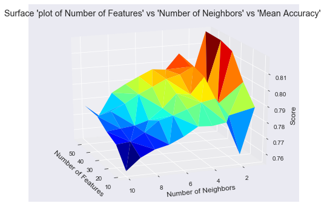

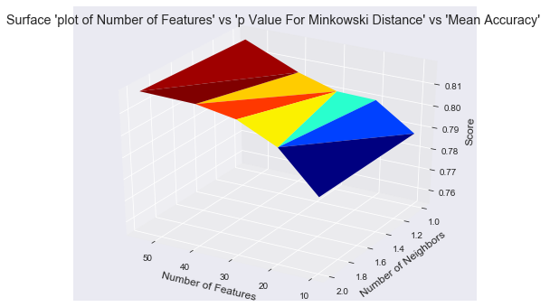

```python
results_KNN = get_search_results(gs_pipe_KNN)

fig = plt.figure(figsize = (8,6))
ax = fig.gca(projection='3d')
ax.plot_trisurf(results_KNN['rfi_fs__n_features_'], results_KNN['knn__n_neighbors'], results_KNN['mean_score'], cmap=plt.cm.jet, linewidth=0.2)
_ = ax.set_xlabel("Number of Features")
_ = ax.set_ylabel("Number of Neighbors")
_ = ax.set_zlabel("Score")
_ = ax.set_title("Surface 'plot of Number of Features' vs 'Number of Neighbors' vs 'Mean Accuracy' ")
_ = ax.view_init(20, 160)
plt.show();

fig = plt.figure(figsize = (8,6))
ax = fig.gca(projection='3d')
ax.plot_trisurf(results_KNN['rfi_fs__n_features_'], results_KNN['knn__p'], results_KNN['mean_score'], cmap=plt.cm.jet, linewidth=0.2)
_ = ax.set_xlabel("Number of Features")
_ = ax.set_ylabel("Number of Neighbors")
_ = ax.set_zlabel("Score")
_ = ax.set_title("Surface 'plot of Number of Features' vs 'p Value For Minkowski Distance' vs 'Mean Accuracy' ")
_ = ax.view_init(30, 120)
plt.show();
```

#### Results

Optimal values for parameters are

```python
gs_pipe_KNN.best_params_
```

[output not shown]

```python
gs_pipe_KNN.best_score_
```

```
0.8189558590033948
```

### Decision Tree Classifier

We will search for the optimal values for maximum depth and minimum sample size for split. We will check with different number of features. The ranges used for search are as follows

- Number of features - 10, 20, 30, 40, 54
- Max Depth - 5, 10, 15, 20, 25, 30, 35
- Min samples for split - 2, 5, 7

```python
# Decision Tree
from sklearn.tree import DecisionTreeClassifier

pipe_DT = Pipeline([('rfi_fs', RFIFeatureSelector()),
                    ('dt', DecisionTreeClassifier(criterion='gini'))])

params_pipe_DT = {'rfi_fs__n_features_': [10, 20, 30, 40, descriptives.shape[1]],
                  'dt__max_depth': [ 5, 10, 15, 20, 25, 30, 35],
                  'dt__min_samples_split': [2, 5, 7],
                 }

gs_pipe_DT = GridSearchCV(estimator=pipe_DT,
                          param_grid=params_pipe_DT,
                          cv=cv_method,
                          refit=True,
                          n_jobs=-2,
                          scoring='accuracy',
                          verbose=1)

gs_pipe_DT.fit(x_train, y_train);
```

```
Fitting 5 folds for each of 105 candidates, totalling 525 fits
```

```
[Parallel(n_jobs=-2)]: Using backend LokyBackend with 7 concurrent workers.
[Parallel(n_jobs=-2)]: Done  36 tasks      | elapsed:   19.0s
[Parallel(n_jobs=-2)]: Done 186 tasks      | elapsed:  1.3min
[Parallel(n_jobs=-2)]: Done 436 tasks      | elapsed:  3.0min
[Parallel(n_jobs=-2)]: Done 525 out of 525 | elapsed:  3.5min finished
```

#### Analysis - Grid Search Decision Tree

It can be seen from the 3d Surface plots below that the performance of models improves with increaseing values for number of features and maximum depth. We get best performance near 40 features and 30 Max depth. However, lower values for min_samples_split perfroms better than higher values.

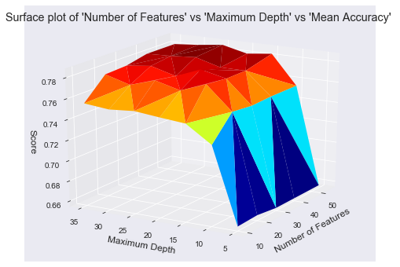

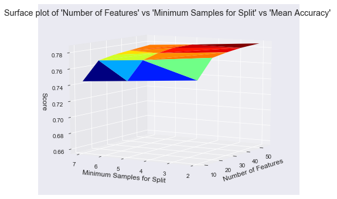

```python
gs_pipe_DT_sr = get_search_results(gs_pipe_DT)

fig = plt.figure(figsize = (8,6))
ax = fig.gca(projection='3d')
ax.plot_trisurf(gs_pipe_DT_sr['rfi_fs__n_features_'], gs_pipe_DT_sr['dt__max_depth'], gs_pipe_DT_sr['mean_score'], cmap=plt.cm.jet, linewidth=0.2)
_ = ax.set_xlabel("Number of Features")
_ = ax.set_ylabel("Maximum Depth")
_ = ax.set_zlabel("Score")
_ = ax.set_title("Surface plot of 'Number of Features' vs 'Maximum Depth' vs 'Mean Accuracy' ")
_ = ax.view_init(20, 210)
plt.show();

fig = plt.figure(figsize = (8,6))
ax = fig.gca(projection='3d')
ax.plot_trisurf(gs_pipe_DT_sr['rfi_fs__n_features_'], gs_pipe_DT_sr['dt__min_samples_split'], gs_pipe_DT_sr['mean_score'], cmap=plt.cm.jet, linewidth=0.2)
_ = ax.set_xlabel("Number of Features")
_ = ax.set_ylabel("Minimum Samples for Split")
_ = ax.set_zlabel("Score")
_ = ax.set_title("Surface plot of 'Number of Features' vs 'Minimum Samples for Split' vs 'Mean Accuracy' ")
_ = ax.view_init(10, 210)
plt.show();
```

#### Results

Optimal values for parameters are

Highest Accuracy = 78.326 %

```python
gs_pipe_DT.best_params_
```

```
{'dt__max_depth': 30, 'dt__min_samples_split': 2, 'rfi_fs__n_features_': 40}
```

```python
gs_pipe_DT.best_score_
```

```
0.7832672430605213
```

### Random Forest Classifier

Grid search for random forest classifier is quite exhastive process in terms of computation time, due to repeatative sub-sampling.

```python
# Random Forest
from sklearn.ensemble import RandomForestClassifier

pipe_RF = Pipeline([('rfi_fs', RFIFeatureSelector()),
                    ('rf', RandomForestClassifier())])

params_pipe_RF = {'rfi_fs__n_features_': [ 30,40, descriptives.shape[1]],
                  'rf__max_depth': [ 10, 20, 40],
                  'rf__min_samples_split': [2, 5],
                  "rf__min_samples_leaf": [1, 3, 10],
                  "rf__criterion": ["gini", "entropy"]}

gs_pipe_RF = GridSearchCV(estimator=pipe_RF,
                          param_grid=params_pipe_RF,
                          cv=cv_method,
                          refit=True,
                          n_jobs=-2,
                          scoring='accuracy',
                          verbose=1)

gs_pipe_RF.fit(x_train, y_train);
```

```
Fitting 5 folds for each of 108 candidates, totalling 540 fits
```

```
[Parallel(n_jobs=-2)]: Using backend LokyBackend with 7 concurrent workers.
[Parallel(n_jobs=-2)]: Done  36 tasks      | elapsed:   29.8s
[Parallel(n_jobs=-2)]: Done 186 tasks      | elapsed:  2.2min
[Parallel(n_jobs=-2)]: Done 436 tasks      | elapsed:  5.5min
[Parallel(n_jobs=-2)]: Done 540 out of 540 | elapsed:  6.9min finished
```

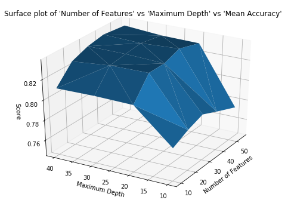

```python
gs_pipe_RF_sr = get_search_results(gs_pipe_RF)
gs_pipe_RF_sr.head()


gs_pipe_RF_sr['mean_score'][0].dtype


fig = plt.figure(figsize = (8,6))
ax = fig.gca(projection='3d')
ax.plot_trisurf(gs_pipe_RF_sr['rfi_fs__n_features_'], gs_pipe_RF_sr['rf__max_depth'], gs_pipe_RF_sr['mean_score'],  linewidth=0.2)
_ = ax.set_xlabel("Number of Features")
_ = ax.set_ylabel("Maximum Depth")
_ = ax.set_zlabel("Score")
_ = ax.set_title("Surface plot of 'Number of Features' vs 'Maximum Depth' vs 'Mean Accuracy' ")
_ = ax.view_init(30, 210)
plt.show();
```

#### Results

Optimal values for parameters are

```python
gs_pipe_RF.best_params_
```

```
{'rf__criterion': 'gini',
 'rf__max_depth': 40,
 'rf__min_samples_leaf': 1,
 'rf__min_samples_split': 2,
 'rfi_fs__n_features_': 40}
```

```python
gs_pipe_RF.best_score_
```

```
0.8636156804142315
```

### Gaussian Naive Bayes Classifier

To tune the parameters of NB Classifier we will only use var_smoothing which is a variant of Laplace smoothing along with different number of features. we have used 40 iterations to search among 200 different values between 10 to (10 ^ -3).

```python
# Naive Bayes
from sklearn.preprocessing import PowerTransformer
descriptives_powertransformed = PowerTransformer().fit_transform(descriptives)
x_train_NB, x_test_NB, y_train_NB, y_test_NB = train_test_split(descriptives_powertransformed, target, test_size = 0.20, random_state = 0)


# y_train_powertransformed = PowerTransformer().fit_transform(method = "box-cox",y_train_NB)
```

```python
from sklearn.naive_bayes import GaussianNB
from sklearn.model_selection import RandomizedSearchCV

pipe_NB = Pipeline([('rfi_fs', RFIFeatureSelector()),
                     ('nb', GaussianNB())])

params_pipe_NB = {'rfi_fs__n_features_': [10, 20,30, 40, descriptives.shape[1]],
                  'nb__var_smoothing': np.logspace(1,-3, num=200)}

n_iter_search = 40
gs_pipe_NB = RandomizedSearchCV(estimator=pipe_NB,
                          param_distributions=params_pipe_NB,
                          cv=cv_method,
                          refit=True,
                          n_jobs=-2,
                          scoring='accuracy',
                          n_iter=n_iter_search,
                          verbose=1)

gs_pipe_NB.fit(x_train, y_train);
```

```
Fitting 5 folds for each of 40 candidates, totalling 200 fits
```

```
[Parallel(n_jobs=-2)]: Using backend LokyBackend with 7 concurrent workers.
[Parallel(n_jobs=-2)]: Done  36 tasks      | elapsed:   18.5s
[Parallel(n_jobs=-2)]: Done 186 tasks      | elapsed:  1.2min
[Parallel(n_jobs=-2)]: Done 200 out of 200 | elapsed:  1.3min finished
```

#### Analysis - Grid Search Gaussian Naive Bayes

From the graph it can be observed that for 20 features score is highest, while it decreases slightly for more than 20 features. smaller value for smoothing parameter has positive impact on the model performance.

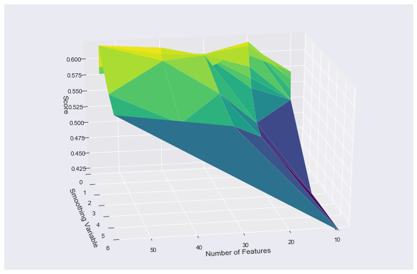

```python
gs_pipe_NB_sr = get_search_results(gs_pipe_NB)
gs_pipe_NB_sr.head()


fig = plt.figure(figsize=(12,8))
ax = fig.gca(projection='3d')
ax.plot_trisurf(gs_pipe_NB_sr['rfi_fs__n_features_'], gs_pipe_NB_sr['nb__var_smoothing'], gs_pipe_NB_sr['mean_score'],  cmap=plt.cm.viridis, linewidth=0.8)
_ = ax.set_xlabel("Number of Features")
_ = ax.set_ylabel("Smoothing Variable")
_ = ax.set_ylim(0,6)
_ = ax.set_zlabel("Score")
_ = ax.view_init(25, 80)
plt.show();
```

#### Results

Optimal values for parameters are

- rfi_fs__n*features* = 20,
- nb__var_smoothing = 0.02121,

Highest Accuracy = 61.600 %

```python
gs_pipe_NB.best_params_
```

```
{'rfi_fs__n_features_': 20, 'nb__var_smoothing': 0.021214517849106298}
```

```python
gs_pipe_NB.best_score_
```

```
0.6160046804914516
```

# Performance Comparision

We have obtained optimal parameters for all 4 classification models using hyper parameter tuning on training dataset. We will apply following steps to find out best performing model for our dataset.

```
* Fit all the otimized model pipeline on test data to retrieve predected target values
* Calculate 'accuracy score' for each model
* Perform pairwise ttests for all 4 models. We will use ttest_rel() method from stats package.
```

Making sure that model score is not influenced by 'lucky-split' or biased data splits, we will use 10 fold cross validation StratifiedKFold without repetation. Parallel processing can be used to speed up the procees. n_jobs= -2 indicates that all the cores except one will be used in the process allowing faster execution.

```python
# KNN
from sklearn.model_selection import cross_val_score

cv_ttest = StratifiedKFold(n_splits=10, random_state=111)

cv_results_KNN = cross_val_score(estimator=gs_pipe_KNN.best_estimator_,
                                 X=x_test,
                                 y=y_test,
                                 cv=cv_ttest,
                                 n_jobs=-2,
                                 scoring='accuracy')
cv_results_KNN.mean()
```

```
0.7329687500000001
```

```python
# Decision Tree
cv_results_DT = cross_val_score(estimator=gs_pipe_DT.best_estimator_,
                                X=x_test,
                                y=y_test,
                                cv=cv_ttest,
                                n_jobs=-2,
                                scoring='accuracy')
cv_results_DT.mean()
```

```
0.7020258387445888
```

```python
# Random Forest
cv_results_RF = cross_val_score(estimator=gs_pipe_RF.best_estimator_,
                                X=x_test,
                                y=y_test,
                                cv=cv_ttest,
                                n_jobs=-2,
                                scoring='accuracy')
cv_results_RF.mean()
```

```
0.8081168831168831
```

```python
# Naive Bayes
cv_results_NB = cross_val_score(estimator=gs_pipe_NB.best_estimator_,
                                X=x_test_NB,
                                y=y_test_NB,
                                cv=cv_ttest,
                                n_jobs=-2,
                                scoring='accuracy')
cv_results_NB.mean()
```

```
0.542637987012987
```

# Significance tests

For pairwise performance assesment of classifiers, we will perform pairwise statistical t-test determining if difference between performance of any two model on our dataset is statistically significant or not. In following code segment, t-test will be used to find statistical significance between following pair or classification models:

- KNN vs DT
- KNN vs RF
- KNN vs NB
- DT vs RF
- DT vs NB
- RF vs NB

Here, for statistical t-test , pvalue lower than 0.05 implies that models have statistically significant difference in terms of performace on test data with best estimators. For such cases, it can be derived that one model outperforms other. Random Forest is statistically best performing classification model(based on Accuracy Score) when applied on test data

```python
cv_results = [cv_results_KNN,cv_results_DT, cv_results_RF, cv_results_NB]
cv_models = ['KNN', 'DT', ' RF', 'NB']
for i in range(0,3):
    for j in range(i+1, 4):
        print(cv_models[i] +' vs ' + cv_models[j])
        print(stats.ttest_rel(cv_results[i], cv_results[j]))
```

```
KNN vs DT
Ttest_relResult(statistic=3.3972050151092397, pvalue=0.007908273013891397)
KNN vs  RF
Ttest_relResult(statistic=-10.812524566289557, pvalue=1.8607855817076091e-06)
KNN vs NB
Ttest_relResult(statistic=18.684322605925228, pvalue=1.653271578777445e-08)
DT vs  RF
Ttest_relResult(statistic=-13.012179806373059, pvalue=3.8518841016819716e-07)
DT vs NB
Ttest_relResult(statistic=24.52471090361534, pvalue=1.492948487973175e-09)
 RF vs NB
Ttest_relResult(statistic=27.25741688125241, pvalue=5.835987260521602e-10)
```

# Testing accuracy comparision

Accuracy score gives us information about how often our model prediction is correct telling whether model is being trained correctly or not. It works well with only balanced data. This constraint is not our concern as we have already created balanced data for training purpose during phase 1 of project.

Classification report can be used to select best classifier according to nature of problem. If false negetive in our data has devastating effect, then choosing a model with lowest recall makes sense. In our case, in order to correctly find a specific cover type in dense forest we should use precision score. As it might cause very high expense in terms of resouces and time to reach to specific area. Hence, it is of most improtant for a model to predict correct data. Random forest has highest precision value among all 4 classification models. Therefore, it should be chosen over other models.

```python
from sklearn import metrics

y_pred_KNN = gs_pipe_KNN.predict(x_test)
metrics.accuracy_score(y_test, y_pred_KNN)
```

```
0.8263130525221009
```

```python
y_pred_DT = gs_pipe_DT.predict(x_test)
metrics.accuracy_score(y_test, y_pred_DT)
```

```
0.797451898075923
```

```python
y_pred_RF = gs_pipe_RF.predict(x_test)
metrics.accuracy_score(y_test, y_pred_RF)
```

```
0.8681747269890796
```

```python
y_pred_NB = gs_pipe_NB.predict(x_test_NB)
metrics.accuracy_score(y_test_NB, y_pred_NB)
```

```
0.5533021320852834
```

```python
print("KNN classifier")
print(metrics.classification_report(y_test, y_pred_KNN))

print("\n\nDecision Tree classifier")
print(metrics.classification_report(y_test, y_pred_DT))

print("\n\nRandom Forest classifier")
print(metrics.classification_report(y_test, y_pred_RF))

print("\n\nNaive bayes classifier")
print(metrics.classification_report(y_test_NB, y_pred_NB))
```

```
KNN classifier
              precision    recall  f1-score   support

           1       0.75      0.73      0.74       542
           2       0.71      0.66      0.69       524
           3       0.80      0.74      0.77       570
           4       0.89      0.94      0.92       535
           5       0.90      0.94      0.92       562
           6       0.77      0.80      0.79       561
           7       0.94      0.95      0.95       552

    accuracy                           0.83      3846
   macro avg       0.82      0.83      0.82      3846
weighted avg       0.82      0.83      0.82      3846



Decision Tree classifier
              precision    recall  f1-score   support

           1       0.68      0.65      0.67       542
           2       0.60      0.61      0.61       524
           3       0.79      0.74      0.76       570
           4       0.92      0.96      0.94       535
           5       0.85      0.91      0.88       562
           6       0.78      0.78      0.78       561
           7       0.94      0.92      0.93       552

    accuracy                           0.80      3846
   macro avg       0.79      0.80      0.80      3846
weighted avg       0.80      0.80      0.80      3846



Random Forest classifier
              precision    recall  f1-score   support

           1       0.80      0.77      0.79       542
           2       0.79      0.73      0.76       524
           3       0.85      0.82      0.83       570
```

[output cut: 10 more lines]

```

Naive bayes classifier
              precision    recall  f1-score   support

           1       0.53      0.47      0.50       542
           2       0.41      0.56      0.48       524
           3       0.41      0.86      0.55       570
           4       0.82      0.58      0.68       535
           5       0.57      0.52      0.54       562
           6       0.52      0.06      0.11       561
           7       0.90      0.82      0.86       552

    accuracy                           0.55      3846
   macro avg       0.59      0.55      0.53      3846
weighted avg       0.59      0.55      0.53      3846
```

# Limitations and Proposed Solutions

In this analysis, we have not used entire dataset available to perform analysis. Main reason behind this is highly imbalanced nature of the target data. Cosidering span of the project, we chose to proceed with undersampling of data. As an advanced step, data can be oversampled and fitted to models to evaluate performance enhancement aligned with number of increased instances.

We have performed hyperparameter tuning with k-fold cross validation. However, due to time and hardware limitations, we could not perform exhaustive grid search cross validation with broader range of hyperparameter space. To overcome this issue, this study can be extended on system with better hardware capabilities.

Moreoever, simple K-fold cross validation(without any repetation) is used here to control processing time. To achieve better optimized results, repeated K-fold can be implemented in pipeline.

In future, this study can be further extended by implementing advanced neural netowrks and deep learning techniques.

# Summary

In this report, we mainly focused on modeling and evaluating a classification problem in pipeline. Data used is already preprocessed in previous phase of the project onn which we applied minmax scaling. We calculated feature importance score and listed 10 most important features contributing to target feature using RandomForestImportance(RFI). Data is divided into 80:20 train:test splits. We stacked feature selection and hyperparameter tuning in a pipeline to obtain optimal parameters. In Pipeline, we have added different number of set of features for selection, diffrent value for relevent parameters of model. Main objective of this entire project is to improve and evaluate performance of four classification models namely K-Nearest Neighbours(KNN), Decision Tree(DT), Random Forest search(RF) and Naive Bayes(NB)- Gaussian. GridSearchCV and RandomSearchCV metods are used on training dataset to otimize hyperparameter for all models. As a final evaluation step, we performed pairwise t-test and generated cross value score by fitting each model on test dataset with achieved bets hyperparameters.

# References

```
Jock A. Blackard and Colorado State University : UCI Machine Learning Repository : covertype dataset https://archive.ics.uci.edu/ml/datasets/covertype
Scikit-learn: Machine Learning in Python, Pedregosa et al., JMLR 12, pp. 2825-2830, 2011 : https://scikit-learn.org/stable/
Ploting graphs : https://python-graph-gallery.com/
```